# Probability and Frequentist Concepts

Ednita Tavarez-Jimenez

## Binomial Probability 1 - 3

**Q1: What is the probability of observing a count of exactly 3 successes in a binomial distribution with parameters n = 4 and p = 0.75? Include your answer and the R code you used to find it.Note: To receive full credit, you cannot use lower.tail = FALSE in your code.**

```r
x_bin = 3
y_bin_2 = pbinom(x_bin, size = 4, prob = .75)

sum(pbinom(x_bin, size = 4, prob = .75))
```

```
## [1] 0.6835937
```

```r
pbinom(q = 3, size = 4, prob = .75)
```

```
## [1] 0.6835937
```

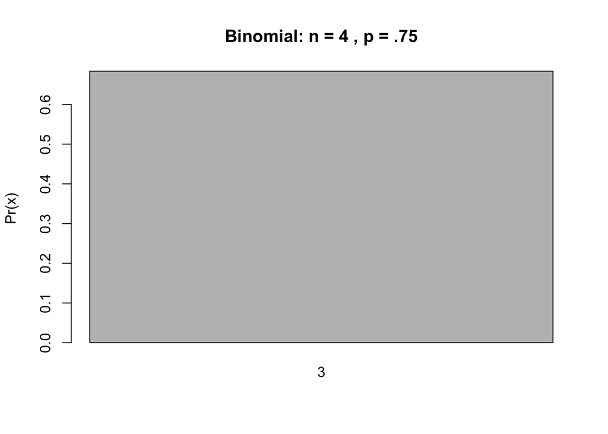

```r
barplot(
  height = y_bin_2,
  # the names to print with each bar:
  names.arg = x_bin,
  # Tells R to remove space between bars:
  space = 0,
  ylab = "Pr(x)",
  main = "Binomial: n = 4 , p = .75")
```

**Q2: What is the probability of observing a count of 3 successes or fewer in a binomial distribution with parameters n = 4 and p = 0.75?**

```r
x_bin = 0:3
y_bin_2 = pbinom(x_bin, size = 4, prob = .75)

sum(pbinom(x_bin, size = 4, prob = .75))
```

```
## [1] 1
```

```r
1-pbinom(q = 3, size = 4, prob = 2/3)
```

```
## [1] 0.1975309
```

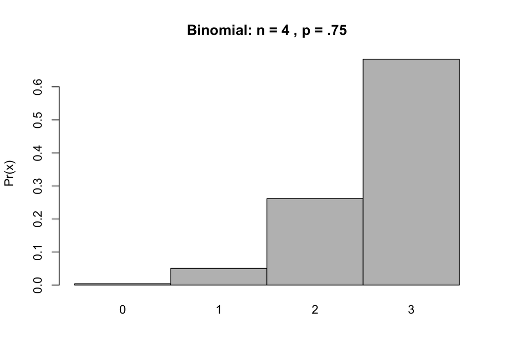

```r
barplot(
  height = y_bin_2,
  # the names to print with each bar:
  names.arg = x_bin,
  # Tells R to remove space between bars:
  space = 0,
  ylab = "Pr(x)",
  main = "Binomial: n = 4 , p = .75")
```

**Q3: What is the probability of observing more than 3 successes in a binomial distribution with parameters n = 5 and p = 0.75?**

```r
x_bin = 4:5
y_bin_2 = pbinom(x_bin, size = 5, prob = .75)

sum(pbinom(x_bin, size = 5, prob = .75))
```

```
## [1] 1.762695
```

```r
1-pbinom(q = 3, size = 5, prob = .75)
```

```
## [1] 0.6328125
```

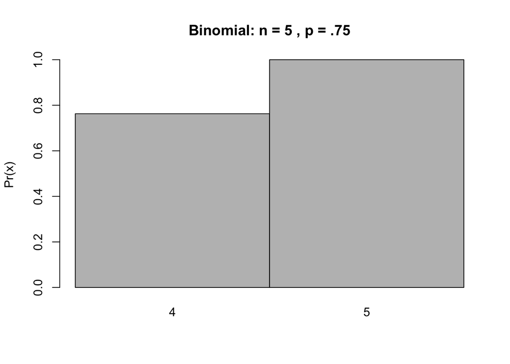

```r
barplot(
  height = y_bin_2,
  # the names to print with each bar:
  names.arg = x_bin,
  # Tells R to remove space between bars:
  space = 0,
  ylab = "Pr(x)",
  main = "Binomial: n = 5 , p = .75")
```

## Normal Probability 1 - 3

**Q4: What is the probability of observing a value of less than 1.2 from a normally-distributed population with mean = 2 and standard deviation = 2**

```r
# Create a vector of x-values from -4 to 4:
pnorm(q = 1.2, mean = 2 , sd = 2)
```

```
## [1] 0.3445783
```

**Q5: What is the probability of observing a value of greater than 1.2 from a normally-distributed population with mean = 2 and standard deviation = 2?**

```r
1 - pnorm(q = 1.2, mean = 2 , sd = 2)
```

```
## [1] 0.6554217
```

**Q6: What is the probability of observing a value between 1.2 and 3.2 from a normally-distributed population with mean = 2 and standard deviation = 2?**

```r
pnorm(3.2, mean = 2, sd = 5,)
```

```
## [1] 0.5948349
```

```r
- pnorm(1.2, mean = 2, sd = 2)
```

```
## [1] -0.3445783
```

## Central Limit Theorem 1

**Q7: Describe how the shape of the histogram changes as you continue to press the sample button.**

As I continue to press the sample button it would continue to be skewed to the left but get longer. However, the first bar is the tallest and doesnt move. The graph pretty much stayed the same in regards to shape.

## Central Limit Theorem 2

**Q8: Describe how the shape of the histogram changes as you continue to press the sample button.**

The histogram moved a little to the right, first bar is now shorter. The bars would get taller and shorter but overall the shape didn’t change it was still skewed to the left.

## Central Limit Theorem 3

**Q9: Describe how the shape of the histogram changes as you continue to press the sample button.**

My graph looks normally distributed and also didn’t change much when I pressed the sample button.

**Q10: Why is there such a drastic change in the shape of the sampling distribution when you change the sample size from 1 to 2?**

When the sample size increases the shape of the of the sample distribution starts to look similar to a normal distribution.

**Q11: What are the two main factors that determine the width of the sampling distribution of the mean?**

Sample size and the population size.

## Library of Babel 1 - 2

**Q12: How many 3-character words are possible?**

25 x 25 x 25 = 25^3 = 15, 625

**Q13: How many books would the Library contain if you added one additional position to the book size? Express your answer in terms of B.**

410 pages 40 rows per page 81 positions per row

```r
410*40*81
```

```
## [1] 1328400
```

```r
B <- 25^1238400
```